# 解密传奇球星科比的真实比赛影响力

PB22151749_黄脉_自己寻找的数据_否

# 第一章 背景

## 1.1传奇球星的科比的生涯简介

科比·布莱恩特（Kobe Bryant）于1978年8月23日出生在美国宾夕法尼亚州费城。1996年，科比在NBA选秀中以第13顺位被夏洛特黄蜂队选中，随后被交易到洛杉矶湖人队。 其整个职业生涯都效力于湖人队（1996-2016）。团队荣誉上，科比帮助球队赢得了五次NBA总冠军（2000, 2001, 2002, 2009, 2010）。同时科比代表美国队参加了两届奥运会（2008, 2012），并获得了两枚金牌。 个人荣誉上，科比18次入选NBA全明星赛，1次获得NBA常规赛MVP（2008），11次入选NBA最佳阵容一队。可惜时不假年，这样一位荣誉等身的篮球运动员于2016年退役，三年多后在一起直升机事故中不幸遇难。 科比不仅以其在篮球场上的卓越表现而闻名，还以其顽强的精神和职业道德激励了无数年轻球员。他的“曼巴精神”（mamba）成为了努力奋斗、不屈不挠的代名词。

## 1.2数据分析目标

近年来，不少新球迷和路人没有看过科比的比赛，加上科比整个职业生涯的14481次投篮打铁（未命中）占据NBA历史第一，导致他们产生了一种误区，认为科比的比赛影响力被过于夸大，从而嘲讽科比为“铁王”。 再者，科比死亡的被不少别有用心的人嘲笑为“耐摔王”、“坠机王”。这些无不使人们对科比的真实比赛影响力产生质疑。科比到底是一个什么水平的球员？相信这是大家心中的疑问。 作为NBA资深球迷，今天就让我来用严谨的数据分析来为大家全面呈现科比20年职业生涯的篮球技艺和比赛影响力。

## 1.3数据分析设计思路

我们从三个方面（空间、时间、对手）来解析科比的进攻。

- 空间上，对科比的投篮方式和投篮位置进行出手数、命中率方面的分析。
- 时间上，研究科比的命中率随着赛季、上场时间的变化。
- 面对不同对手，研究科比的命中率和投篮方式。
- 利用xgboost算法预测列“shot_made_flag”中的缺失值。

# 第二章 数据读取和概览

我们要使用的数据来源于知乎用户在体育专区的分享，其超链接如下： https://pan.baidu.com/link/zhihu/7RhGzTuShjiGNL5kFEM3VU1yaybTpFTwdahT== 我们将其下载到文件“kobe_shoot.csv”。

## 2.1加载R包

```r
library(ggplot2)
library(gridExtra)
library(tidyverse)
library(dplyr)
library(treemap)
library(xgboost)
library(data.table)
library(Matrix)
```

## 2.2导入数据

```r
kobe<-read.csv("kobe_shoot.csv",header = T,as.is = TRUE)
```

检查数据中所包含缺失值的行。

```r
# 计算有缺失值的行数
kobe <- read.csv("kobe_shoot.csv", header = TRUE)
num_na_rows <- sum(is.na(kobe))
cat("有缺失值的行数:", num_na_rows)
```

```
## 有缺失值的行数: 5000
```

```r
# 计算每列的缺失值行数
num_na_per_column <- colSums(is.na(kobe))
print(num_na_per_column)
```

```
##        action_type combined_shot_type      game_event_id            game_id
##                  0                  0                  0                  0
##                lat              loc_x              loc_y                lon
##                  0                  0                  0                  0
##  minutes_remaining             period           playoffs             season
##                  0                  0                  0                  0
##  seconds_remaining      shot_distance     shot_made_flag          shot_type
##                  0                  0               5000                  0
##     shot_zone_area    shot_zone_basic    shot_zone_range            team_id
##                  0                  0                  0                  0
##          team_name          game_date            matchup           opponent
##                  0                  0                  0                  0
##            shot_id
##                  0
```

我们可以看到数据中只有列“shot_made_flag ”中含有缺失值，且有5000行之多，故我们在这里预处理数据时不能冒然将含有缺失值的行删去。 在后面处理有关列“shot_made_flag ”操作时，我们再对数据进行处理。

## 2.3概览数据集

```r
#下面的代码初步展示了数据集的大小和结构。
glimpse(kobe)
```

```
## Rows: 30,697
## Columns: 25
## $ action_type        <chr> "Jump Shot", "Jump Shot", "Jump Shot", "Jump Shot",…
## $ combined_shot_type <chr> "Jump Shot", "Jump Shot", "Jump Shot", "Jump Shot",…
## $ game_event_id      <int> 10, 12, 35, 43, 155, 244, 251, 254, 265, 294, 309, …
## $ game_id            <int> 20000012, 20000012, 20000012, 20000012, 20000012, 2…
## $ lat                <dbl> 33.9723, 34.0443, 33.9093, 33.8693, 34.0443, 34.055…
## $ loc_x              <int> 167, -157, -101, 138, 0, -145, 0, 1, -65, -33, -94,…
## $ loc_y              <int> 72, 0, 135, 175, 0, -11, 0, 28, 108, 125, 238, 127,…
## $ lon                <dbl> -118.1028, -118.4268, -118.3708, -118.1318, -118.26…
## $ minutes_remaining  <int> 10, 10, 7, 6, 6, 9, 8, 8, 6, 3, 1, 11, 7, 2, 1, 0, …
## $ period             <int> 1, 1, 1, 1, 2, 3, 3, 3, 3, 3, 3, 1, 1, 1, 1, 1, 1, …
## $ playoffs           <int> 0, 0, 0, 0, 0, 0, 0, 0, 0, 0, 0, 0, 0, 0, 0, 0, 0, …
## $ season             <chr> "Jan-00", "Jan-00", "Jan-00", "Jan-00", "Jan-00", "…
## $ seconds_remaining  <int> 27, 22, 45, 52, 19, 32, 52, 5, 12, 36, 56, 0, 9, 44…
## $ shot_distance      <int> 18, 15, 16, 22, 0, 14, 0, 2, 12, 12, 25, 17, 12, 9,…
## $ shot_made_flag     <int> NA, 0, 1, 0, 1, 0, 1, NA, 1, 0, 0, 1, 1, 0, 0, 0, N…
## $ shot_type          <chr> "2PT Field Goal", "2PT Field Goal", "2PT Field Goal…
## $ shot_zone_area     <chr> "Right Side(R)", "Left Side(L)", "Left Side Center(…
## $ shot_zone_basic    <chr> "Mid-Range", "Mid-Range", "Mid-Range", "Mid-Range",…
## $ shot_zone_range    <chr> "16-24 ft.", "8-16 ft.", "16-24 ft.", "16-24 ft.", …
## $ team_id            <int> 1610612747, 1610612747, 1610612747, 1610612747, 161…
## $ team_name          <chr> "Los Angeles Lakers", "Los Angeles Lakers", "Los An…
## $ game_date          <chr> "2000/10/31", "2000/10/31", "2000/10/31", "2000/10/…
## $ matchup            <chr> "LAL @ POR", "LAL @ POR", "LAL @ POR", "LAL @ POR",…
## $ opponent           <chr> "POR", "POR", "POR", "POR", "POR", "POR", "POR", "P…
## $ shot_id            <int> 1, 2, 3, 4, 5, 6, 7, 8, 9, 10, 11, 12, 13, 14, 15, …
```

## 2.4变量解释

```r
#action_type                   投篮方式（细分）

#combined_shot_type           投篮方式(大类)
#其中Jump Shot（跳投）、Bank Shot（打板投篮）、Dunk（扣篮）
#Hook Shot（勾手投篮）、Layup （上篮）、Tip Shot（补篮）

#game_event_id                比赛时间ID

#game_id                      比赛ID

#lat                          投篮点

#loc_x                        投篮点

#loc_y                        投篮点

#lon                          投篮点

#minutes_remaining            单节剩余时间（分钟）

#period                       表示第几节

#playoffs                     是否是季后赛

#season                       赛季

#seconds_remaining            剩余时间（秒）

#shot_distance                投篮距离

#shot_made_flag               是否进球

#shot_type                    两分球或三分球

#shot_zone_area               投篮区域

#shot_zone_basic              投篮区域（更具体）

#shot_zone_range              投篮范围

#team_id                      球队ID

#team_name                    球队名称

#game_date                    比赛日期

#matchup                      比赛双方

#opponent                     对手

#shot_id                      投篮ID
```

# 第三章 科比在不同空间的表现

## 3.1投篮方式分析

### 3.1.1两分和三分出手占比

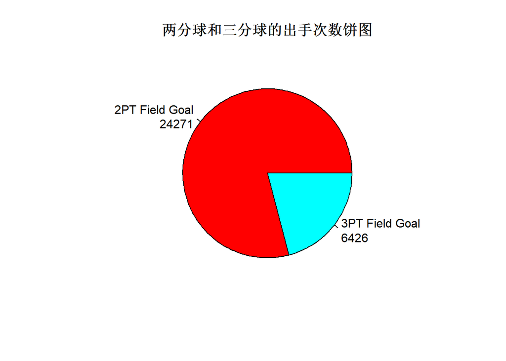

```r
tb2<-table(kobe$shot_type)
lbl<-paste(names(tb2),"\n",tb2,sep = "")
pie(tb2,labels=lbl,col=rainbow(length(tb2)),
main = "两分球和三分球的出手次数饼图")
```

可以从饼图直观的看出科比在整个生涯两分球出手次数大约是三分球出手次数的四倍。这说明科比在尽量追求高效率的两分球，打法整体十分稳健。

### 3.1.2各种投篮方式（大类）在篮球场上的点位分布

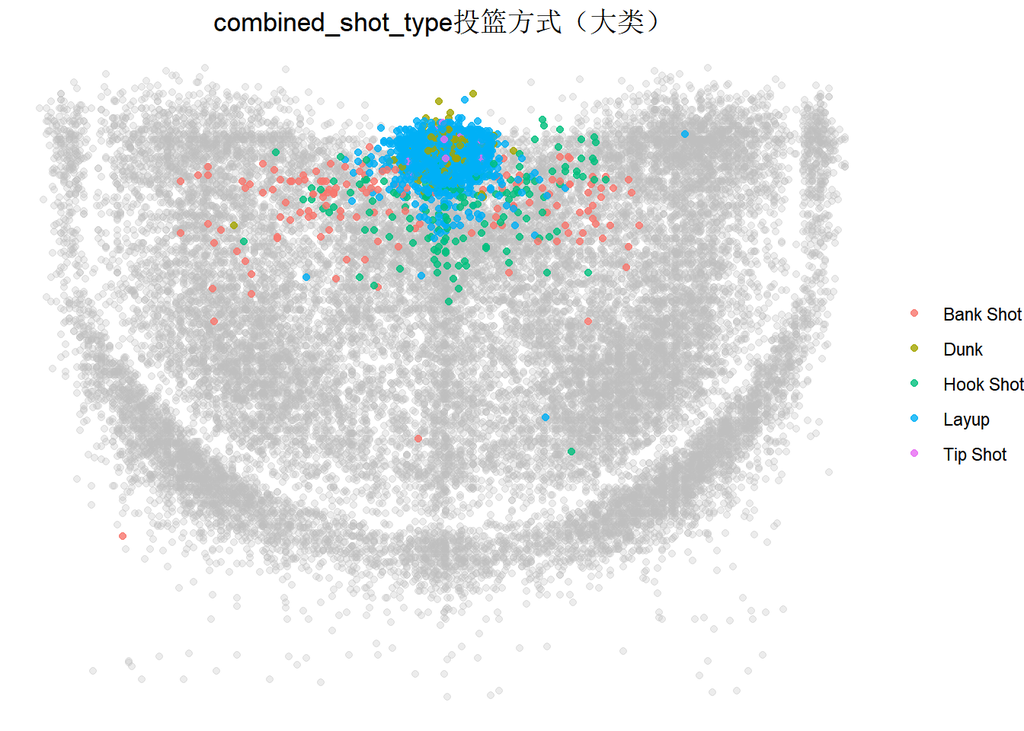

```r
# 筛选出不包含缺失值的数据点
kobe_filtered <- kobe %>%
  filter(!is.na(lat) & !is.na(lon) & !is.na(combined_shot_type))#其实这步可以省去，因为前面的预处理已经告诉我们只有列“shot_made_flag ”才有缺失值

# 定义经纬度范围
lat_range <- c(33.7, 34.0883)
lon_range <- range(kobe_filtered$lon)  # 根据实际数据范围设置经度

# 在指定范围内筛选数据点
kobe_filtered <- kobe_filtered %>%
  filter(lat >= lat_range[1] & lat <= lat_range[2] &
         lon >= lon_range[1] & lon <= lon_range[2])
ggplot() +
  geom_point(data=kobe_filtered %>% filter(combined_shot_type=="Jump Shot"),aes(x=lon, y=lat), colour="grey", alpha=0.3) +
  geom_point(data=kobe_filtered %>% filter(combined_shot_type!="Jump Shot"), aes(x=lon, y=lat, colour=combined_shot_type), alpha=0.8) +
  labs(title="combined_shot_type投篮方式（大类）") +ylim(c(33.7, 34.0883)) +theme_void() +
  theme(legend.title=element_blank(),plot.title=element_text(hjust=0.5))
```

虽然我们开头已经知道只有列“shot_made_flag ”中含有缺失值，但出于严谨性，我还是在此进行了含有缺失值的行的筛除，后面的若有则同理。 放眼进攻半场，科比在每个位置都有大量的Jump Shot（跳投），在靠近篮筐的地方进行大量的Layup （上篮）和零星的Tip Shot（补篮）、Dunk（扣篮），在距离篮筐不远的两侧有着数量中等的Bank Shot（打板投篮）和Hook Shot（勾手投篮）。

- Bank Shot（打板投篮）的分布非常合理，因为只有在斜对着篮筐出手时Bank Shot（打板投篮）的命中率最高。
- Layup （上篮）的分布也非常合理,科比在上篮过程遇到篮底中锋的防守时并未急于出手，而是尽可能地靠近篮筐才出手，保证命中率的最大化。
- 在任意位置都有大量的Jump Shot（跳投）从侧面说明科比的进攻手段的丰富，无论面对高大中锋还是敏捷后卫的防守，科比都能完成Jump Shot（跳投）出手。

### 3.1.3各种投篮方式（大类）所占比例

```r
 d1<-data.frame(table(kobe$combined_shot_type))
d1
```

```
##        Var1  Freq
## 1 Bank Shot   141
## 2      Dunk  1286
## 3 Hook Shot   153
## 4 Jump Shot 23485
## 5     Layup  5448
## 6  Tip Shot   184
```

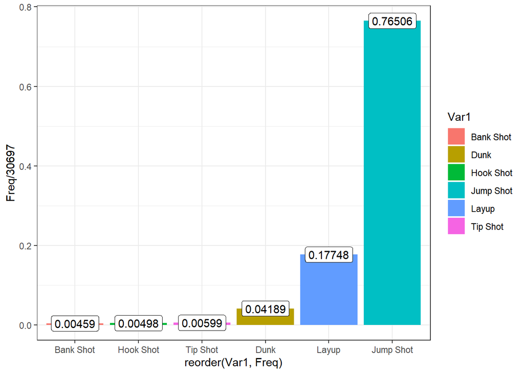

```r
ggplot(d1,aes(x=reorder(Var1,Freq),y=Freq/30697))+
  geom_col(aes(fill=Var1))+
  geom_label(aes(label=round(Freq/30697,5)))+
  theme_bw()
```

- 从结果图中看出来，Hook Shot(勾手投篮)、Tip Shoot(补篮)和Bank Shoot(擦板投篮)是科比很少使用的进攻方式，Jump Shoot(跳投)是他最常用的方式。
- 这说明比科比并不是一个以攻筐为主的后卫（攻筐后卫代表有威少、罗斯），而是一个在外线大量投篮的后卫。这样做的好处显而易见，外线的频繁出手可以吸引敌方的“重点关照”，为己方中锋拉开空间，间接削弱己方内线所面临的防守强度。
- 科比搭档过的内线队友无不印证这一事实，他们在来到科比身边后无论是出手数还是命中率都迎来了上涨。

### 3.1.4各种投篮方式（细分）的命中率

```r
# 删除含有NA值的行
kobe_clean1 <- kobe[complete.cases(kobe), ]

# 删除`action_type`列中的NA值
kobe_clean1 <- kobe_clean1[!is.na(kobe_clean1$action_type), ]

# 确认清理后的数据集
print(dim(kobe_clean1))
```

```
## [1] 25697    25
```

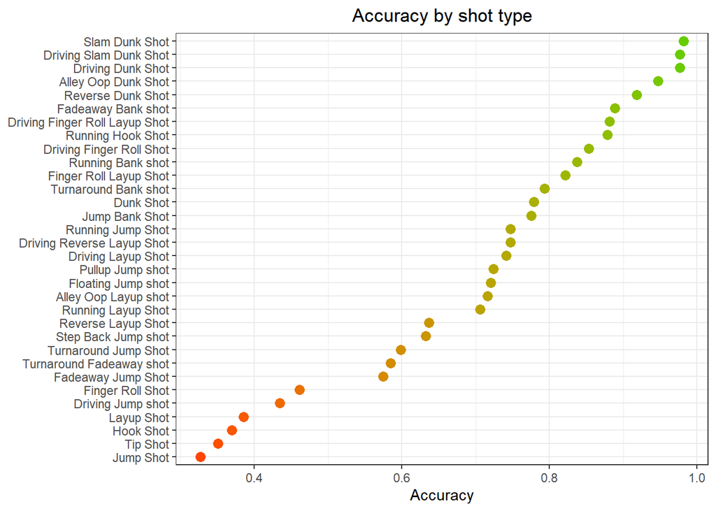

```r
kobe_clean1 %>%
  group_by(action_type) %>%
  summarise(Accuracy = mean(shot_made_flag),
            counts = n()) %>%
  filter(counts > 20) %>%
  ggplot(aes(x = reorder(action_type, Accuracy), y = Accuracy)) +
  geom_point(aes(colour = Accuracy), size = 3) +
  scale_colour_gradient(low = "orangered", high = "chartreuse3") +
  labs(title = "Accuracy by shot type") +
  theme_bw() +
  theme(axis.title.y = element_blank(),
        legend.position = "none",
        plot.title = element_text(hjust = 0.5)) +
  coord_flip()
```

- 可以看出在细分的32类投篮方式中，大类投篮方式命中率从低到高排序为Jump Shot（跳投）、Tip Shot（补篮）、Hook Shot（勾手投篮）、Layup （上篮）、Bank Shot（打板投篮）、Dunk（扣篮）。
- Turnaround Shoot（翻身跳投）这种对身体素质要求极高的投篮方式命中率竟然逼近60%，足以说明科比变态的腰腹力量和炉火纯青的背身技术。
- 所有带有Running（跑动）的投篮方式命中率均超过60%，说明科比的运动能力极佳，能够在高速移动中完成复杂动作。
- 32类投篮方式说明了科比的技术全能，掌握了人类篮球后卫中所有的终结技巧。

### 3.1.5各种投篮方式（大类+细分）的命中率

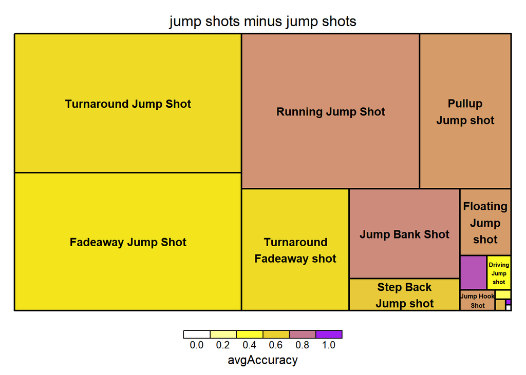

```r
group_cols <- c("combined_shot_type", "action_type") # columns to group by
dots <- lapply(group_cols, as.symbol) # convert to list
tableDF <- kobe %>%
  group_by_(.dots=dots) %>%
  summarise(attempted = n(), avgAccuracy = mean(shot_made_flag, na.rm = TRUE))
custom_hues <- c( rep("white",3), "yellow","purple" ) # make custom palette
treemap(tableDF[tableDF$combined_shot_type == "Jump Shot" & tableDF$action_type != "Jump Shot",],
        index = "action_type", # only one level
        vSize = "attempted",
        vColor = "avgAccuracy",
        type = "value",
        title = "jump shots minus jump shots",
        overlap.labels = 0.2, # avoid overlaps
        palette = custom_hues
        )
```

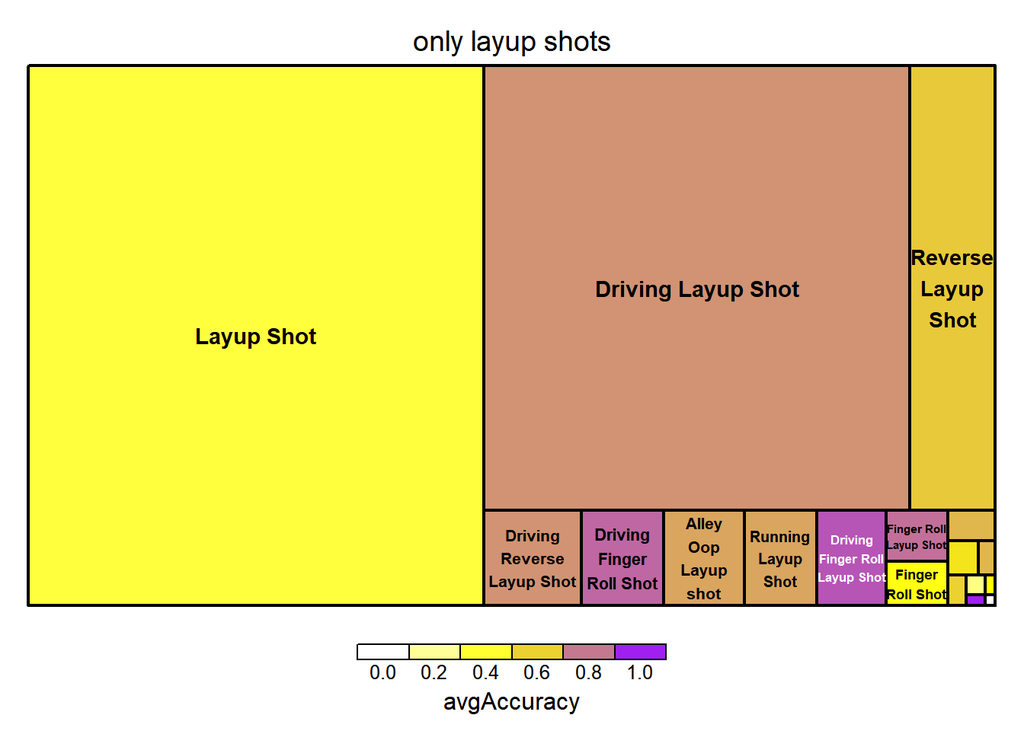

```r
treemap(tableDF[tableDF$combined_shot_type == "Layup",],
        index = "action_type", # only one level
        vSize = "attempted",
        vColor = "avgAccuracy",
        type = "value",
        title = "only layup shots",
        overlap.labels = 0.2, # avoid overlaps
        palette = custom_hues
        )
```

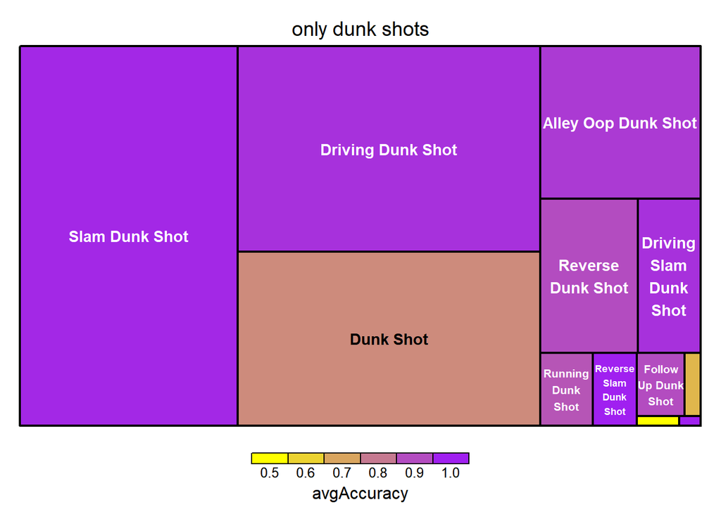

```r
treemap(tableDF[tableDF$combined_shot_type == "Dunk",],
        index = "action_type", # only one level
        vSize = "attempted",
        vColor = "avgAccuracy",
        type = "value",
        title = "only dunk shots",
        overlap.labels = 0.2, # avoid overlaps
        palette = custom_hues
        )
```

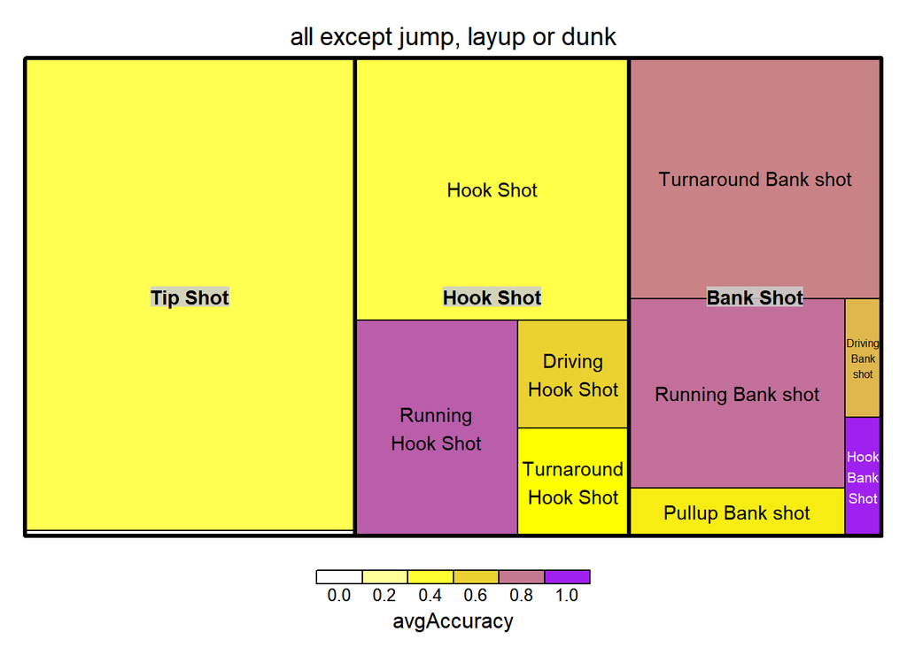

```r
treemap(tableDF[! tableDF$combined_shot_type %in% c("Jump Shot","Layup","Dunk"),],
        index = c("combined_shot_type", "action_type"), # two hierarchy levels
        vSize = "attempted",
        vColor = "avgAccuracy",
        type = "value",
        title = "all except jump, layup or dunk",
        overlap.labels = 0.2, # avoid overlaps
        palette = custom_hues
        )
```

## 3.2投篮位置分析

### 3.2.1不同投篮范围的出手占比

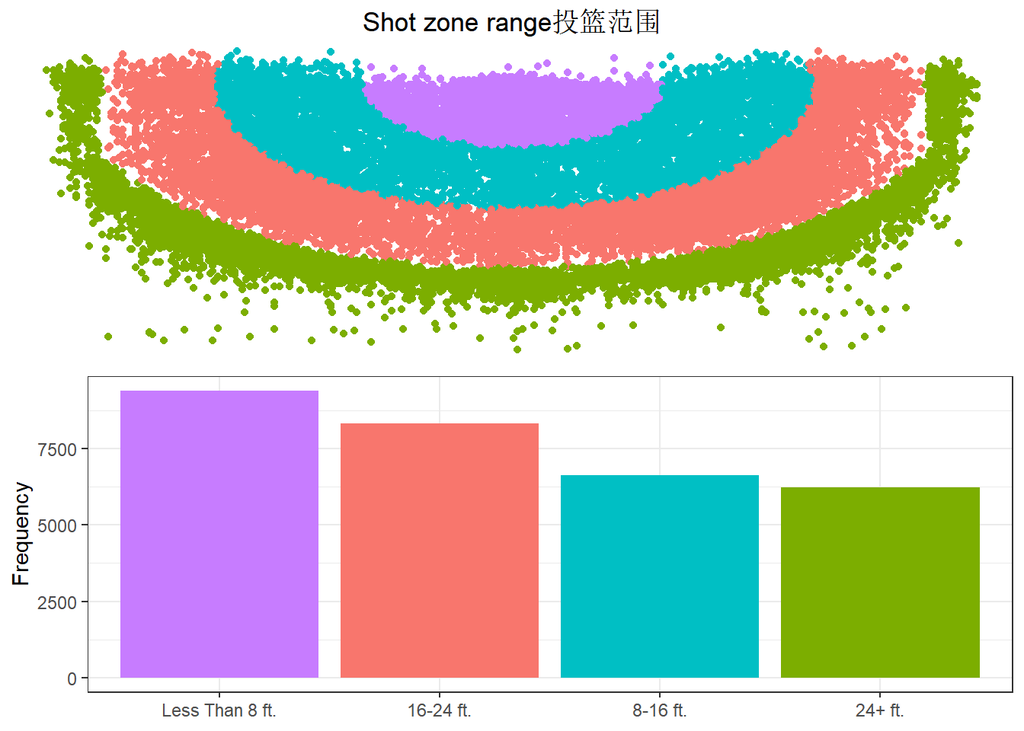

```r
# 筛选出不包含缺失值的数据点
kobe_filtered <- kobe %>%
  filter(!is.na(lat) & !is.na(lon) & !is.na(shot_zone_range))#其实这步可以省去，因为前面的预处理已经告诉我们只有列“shot_made_flag ”才有缺失值

# 定义经纬度范围
lat_range <- c(33.7, 34.0883)
lon_range <- range(kobe_filtered$lon)  # 根据实际数据范围设置经度

# 在指定范围内筛选数据点
kobe_filtered <- kobe_filtered %>%
  filter(lat >= lat_range[1] & lat <= lat_range[2] &
         lon >= lon_range[1] & lon <= lon_range[2])

p1 <- ggplot(kobe_filtered, aes(x=lon, y=lat)) +
  geom_point(aes(color=shot_zone_range)) +
  labs(title="Shot zone range投篮范围") +
  ylim(c(33.7, 34.0883)) +
  theme_void() +
  theme(legend.position="none", plot.title=element_text(hjust=0.5))

p2 <- ggplot(kobe_filtered, aes(x=fct_infreq(shot_zone_range))) +
  geom_bar(aes(fill=shot_zone_range)) +
  labs(y="Frequency") +
  theme_bw() +
  theme(axis.title.x=element_blank(),  legend.position="none")
grid.arrange(p1, p2, layout_matrix=cbind(c(1,2)))
```

### 3.2.2不同投篮区域的出手占比

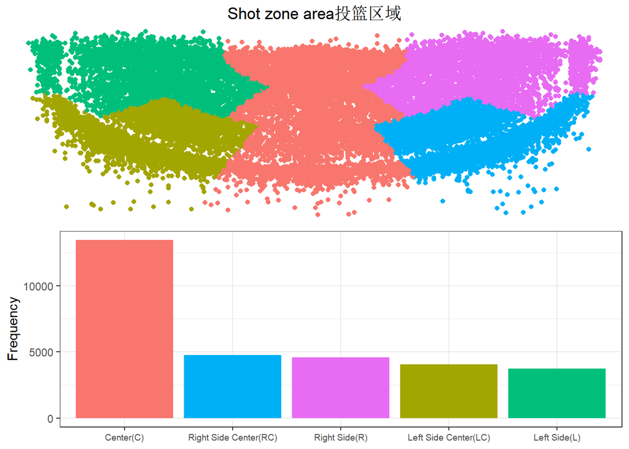

```r
# 筛选出不包含缺失值的数据点
kobe_filtered <- kobe %>%
  filter(!is.na(lat) & !is.na(lon) & !is.na(shot_zone_area))#其实这步可以省去，因为前面的预处理已经告诉我们只有列“shot_made_flag ”才有缺失值

# 定义经纬度范围
lat_range <- c(33.7, 34.0883)
lon_range <- range(kobe_filtered$lon)  # 根据实际数据范围设置经度

# 在指定范围内筛选数据点
kobe_filtered <- kobe_filtered %>%
  filter(lat >= lat_range[1] & lat <= lat_range[2] &
         lon >= lon_range[1] & lon <= lon_range[2])

p3 <- ggplot(kobe_filtered, aes(x=lon, y=lat)) +
  geom_point(aes(colour=shot_zone_area)) +
  labs(title="Shot zone area投篮区域") +
  ylim(c(33.7, 34.0883)) +
  theme_void() +
  theme(legend.position="none", plot.title=element_text(hjust=0.5))

p4 <- ggplot(kobe_filtered, aes(x=fct_infreq(shot_zone_area))) +
  geom_bar(aes(fill=shot_zone_area)) +
  labs(y="Frequency") +
  theme_bw() +
  theme(axis.text.x=element_text(size=7),axis.title.x=element_blank(), legend.position="none")

grid.arrange(p3, p4, layout_matrix=cbind(c(1,2)))
```

- 在篮筐的中轴线区域的出手压倒性地多于两翼，说明科比更喜欢面向框进攻而并非在两翼侧身进攻。

### 3.2.3不同投篮区域（更具体）的出手占比

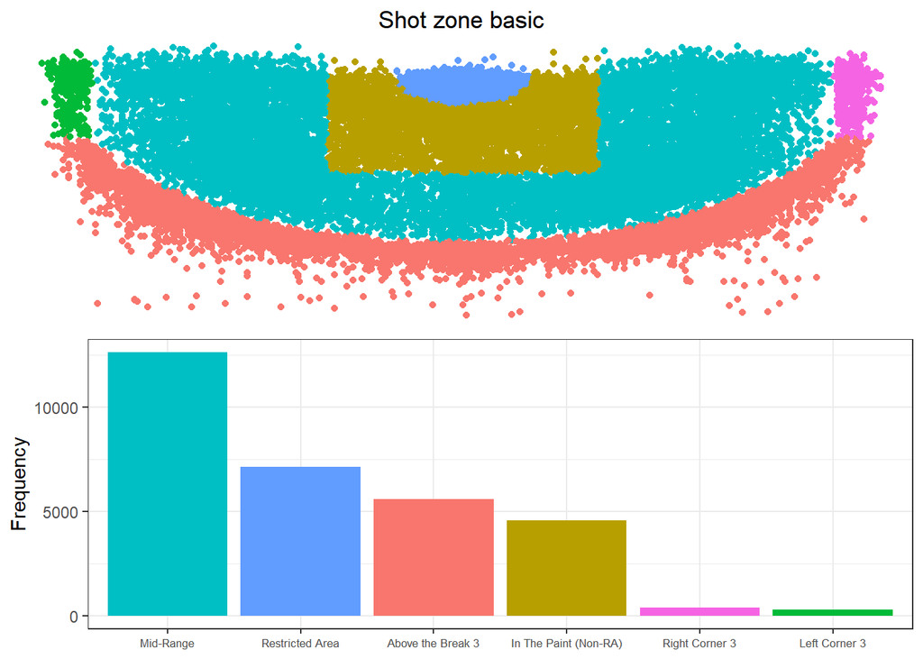

```r
# 筛选出不包含缺失值的数据点
kobe_filtered <- kobe %>%
  filter(!is.na(lat) & !is.na(lon) & !is.na(shot_zone_basic))#其实这步可以省去，因为前面的预处理已经告诉我们只有列“shot_made_flag ”才有缺失值

# 定义经纬度范围
lat_range <- c(33.7, 34.0883)
lon_range <- range(kobe_filtered$lon)  # 根据实际数据范围设置经度

# 在指定范围内筛选数据点
kobe_filtered <- kobe_filtered %>%
  filter(lat >= lat_range[1] & lat <= lat_range[2] &
         lon >= lon_range[1] & lon <= lon_range[2])

p5 <- ggplot(kobe_filtered, aes(x=lon, y=lat)) +
  geom_point(aes(color=shot_zone_basic)) +
  labs(title="Shot zone basic") +
  ylim(c(33.7, 34.0883)) +
  theme_void() +
  theme(legend.position="none", plot.title=element_text(hjust=0.5))

p6 <- ggplot(kobe_filtered, aes(x=fct_infreq(shot_zone_basic))) +
  geom_bar(aes(fill=shot_zone_basic)) +
  labs(y="Frequency") +
  theme_bw() +
  theme(axis.text.x=element_text(size=6.3), axis.title.x=element_blank(), legend.position="none")

grid.arrange(p5, p6, layout_matrix=cbind(c(1,2)))
```

- 科比的三分球投射集中于上三分线位置，在左右底角的三分远投占比极小，说明科比并不擅长在底角做一个接球投手。中距离的占比较高，这一区域也是能更好进行各种复杂技术动作的区域，能极大发挥科比的技术特性。限制区和肘区的出手次数加起来较高，说明科比有足够能力在近筐区域创造出手机会。

### 3.2.4不同投篮范围、区域、区域（更具体）的命中率

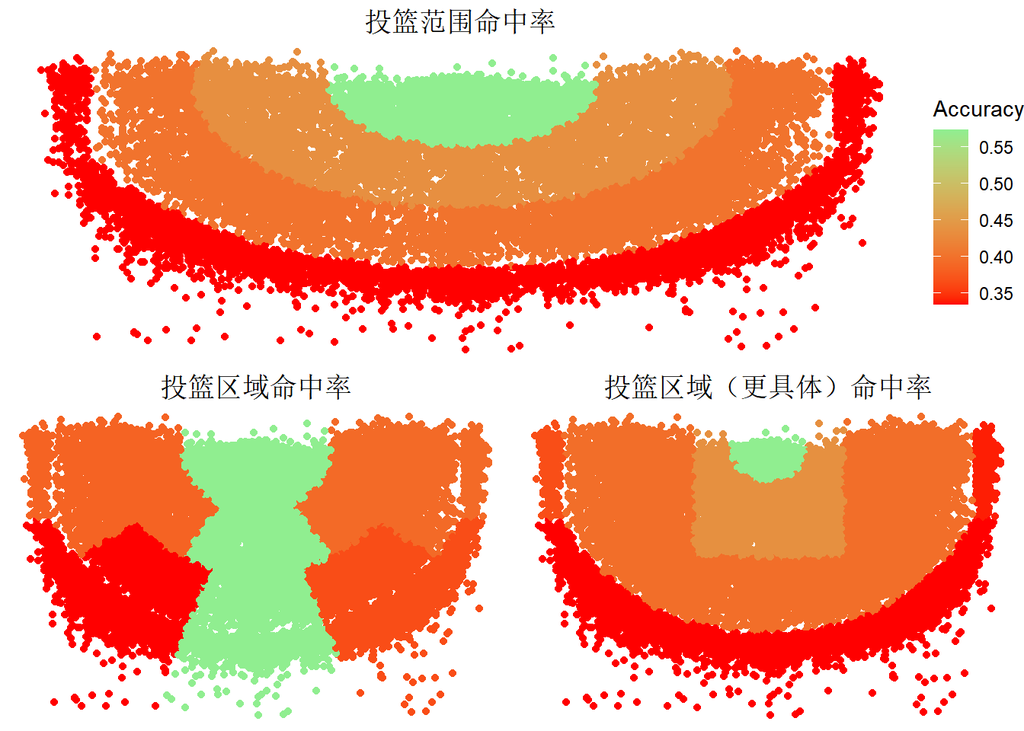

```r
# 筛选出不包含缺失值的数据点
kobe_filtered <- kobe %>%
  filter(!is.na(lat) & !is.na(lon) & !is.na(shot_zone_range) & !is.na(shot_zone_area) & !is.na(shot_zone_basic) & !is.na(shot_made_flag))

# 定义经纬度范围
lat_range <- c(33.7, 34.0883)
lon_range <- range(kobe_filtered$lon)  # 根据实际数据范围设置经度

# 在指定范围内筛选数据点
kobe_filtered <- kobe_filtered %>%
  filter(lat >= lat_range[1] & lat <= lat_range[2] &
         lon >= lon_range[1] & lon <= lon_range[2])

p7 <- kobe_filtered %>%
  select(lat, lon, shot_zone_range, shot_made_flag) %>%
  group_by(shot_zone_range) %>%
  mutate(Accuracy=mean(shot_made_flag)) %>%
  ggplot(aes(x=lon, y=lat)) +
  geom_point(aes(colour=Accuracy)) +
  scale_colour_gradient(low="red", high="lightgreen") +
  labs(title="投篮范围命中率") +
  ylim(lat_range) +
  theme_void() +
  theme(plot.title=element_text(hjust=0.5))


p8 <- kobe_filtered %>%
  select(lat, lon, shot_zone_area, shot_made_flag) %>%
  group_by(shot_zone_area) %>%
  mutate(Accuracy=mean(shot_made_flag)) %>%
  ggplot(aes(x=lon, y=lat)) +
  geom_point(aes(colour=Accuracy)) +
  scale_colour_gradient(low="red", high="lightgreen") +
  labs(title="投篮区域命中率") +
  ylim(lat_range) +
  theme_void() +
  theme(legend.position="none",
        plot.title=element_text(hjust=0.5))


p9 <- kobe_filtered %>%
  select(lat, lon, shot_zone_basic, shot_made_flag) %>%
  group_by(shot_zone_basic) %>%
  mutate(Accuracy=mean(shot_made_flag)) %>%
  ggplot(aes(x=lon, y=lat)) +
  geom_point(aes(colour=Accuracy)) +
  scale_colour_gradient(low="red", high="lightgreen") +
  labs(title="投篮区域（更具体）命中率") +
  ylim(lat_range) +
  theme_void() +
  theme(legend.position="none",
        plot.title=element_text(hjust=0.5))

# 排列子图
grid.arrange(p7, p8, p9, layout_matrix=cbind(c(1,2), c(1,3)))
```

- 结合前文的出手占比，足以说明科比能够在低位和篮筐中轴线区域进行大量且高效的出手，在中距离进行大量且中高效的出手，在三分线进行少量且效率一般的出手。

### 3.2.5不同距离的命中率

```r
# 检查数据集中是否有缺失值或不在指定范围内的值
summary(kobe$shot_distance)
```

```
##    Min. 1st Qu.  Median    Mean 3rd Qu.    Max.
##    0.00    5.00   15.00   13.44   21.00   79.00
```

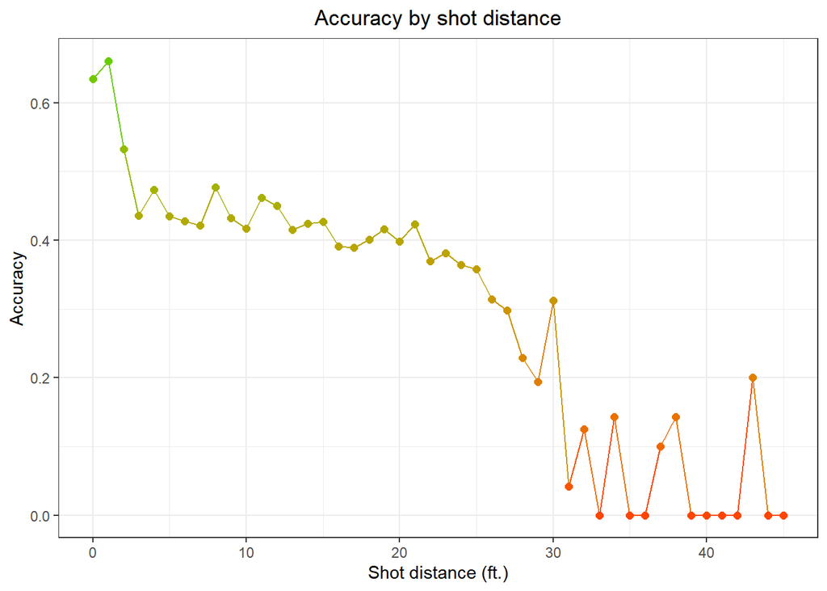

```r
# 删除含有缺失值或不在指定范围内的值的行
kobe_clean2 <- kobe[complete.cases(kobe) & kobe$shot_distance >= 0 & kobe$shot_distance <= 45, ]

# 重新绘制图形
kobe_clean2 %>%
  group_by(shot_distance) %>%
  summarise(Accuracy = mean(shot_made_flag)) %>%
  ggplot(aes(x = shot_distance, y = Accuracy)) +
  geom_line(aes(colour = Accuracy)) +
  geom_point(aes(colour = Accuracy), size = 2) +
  scale_colour_gradient(low = "orangered", high = "chartreuse3") +
  labs(title = "Accuracy by shot distance", x = "Shot distance (ft.)") +
  xlim(c(0, 45)) +
  theme_bw() +
  theme(legend.position = "none",
        plot.title = element_text(hjust = 0.5))
```

- 直观感受距离对命中率的影响，1到3英寸和25到29英寸命中率显著下滑，4英寸到24英寸命中率缓慢下滑，30英寸外命中率则波动较大。

# 第四章 科比在不同时间的表现

## 4.1赛季变化

### 4.1.1整体命中率随赛季变化的趋势

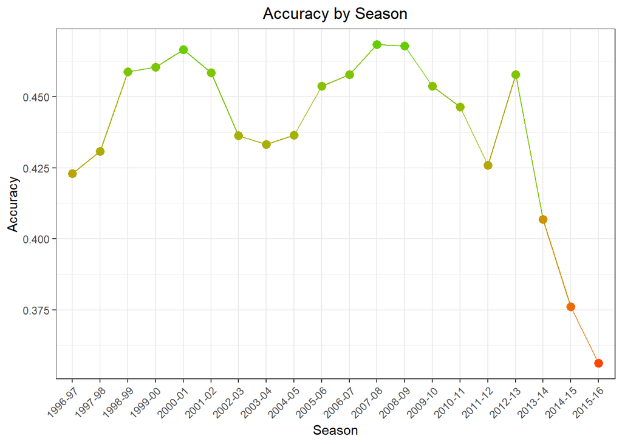

```r
# 确保kobe数据集中没有缺失值并在绘图范围内
kobe_clean <- kobe %>%
  filter(!is.na(shot_made_flag))
kobe_clean[kobe_clean$season=="Jan-00","season"]<-"2000-01"
kobe_clean[kobe_clean$season=="Feb-01","season"]<-"2001-02"
kobe_clean[kobe_clean$season=="Mar-02","season"]<-"2002-03"
kobe_clean[kobe_clean$season=="Apr-03","season"]<-"2003-04"
kobe_clean[kobe_clean$season=="May-04","season"]<-"2004-05"
kobe_clean[kobe_clean$season=="Jun-05","season"]<-"2005-06"
kobe_clean[kobe_clean$season=="Jul-06","season"]<-"2006-07"
kobe_clean[kobe_clean$season=="Aug-07","season"]<-"2007-08"
kobe_clean[kobe_clean$season=="Sep-08","season"]<-"2008-09"
kobe_clean[kobe_clean$season=="Oct-09","season"]<-"2009-10"
kobe_clean[kobe_clean$season=="Nov-10","season"]<-"2010-11"
kobe_clean[kobe_clean$season=="Dec-11","season"]<-"2011-12"

kobe_clean %>%
  group_by(season) %>%
  summarise(Accuracy = mean(shot_made_flag, na.rm = TRUE)) %>%
  ggplot(aes(x = season, y = Accuracy, group = 1)) +
  geom_line(aes(colour = Accuracy)) +
  geom_point(aes(colour = Accuracy), size = 3) +
  scale_colour_gradient(low = "orangered", high = "chartreuse3") +
  labs(title = "Accuracy by Season", x = "Season") +
  theme_bw() +
  theme(
    legend.position = "none",
    axis.text.x = element_text(angle = 45, hjust = 1),
    plot.title = element_text(hjust = 0.5)
  )
```

- 由于数据集的存储错误，先对数据集赛季内容进行一一替换。
- 科比总共有10个赛季命中率超过45%，表明其巅峰超长。1996-1999属于成长期（仅仅过了2年便成为联盟顶级后卫 ），2002-2005由于没有好的帮手而下滑，2013年遭遇大伤加上年龄已大，从此以后便迅速下滑。

### 4.1.2两分球、三分球命中率随赛季变化的趋势

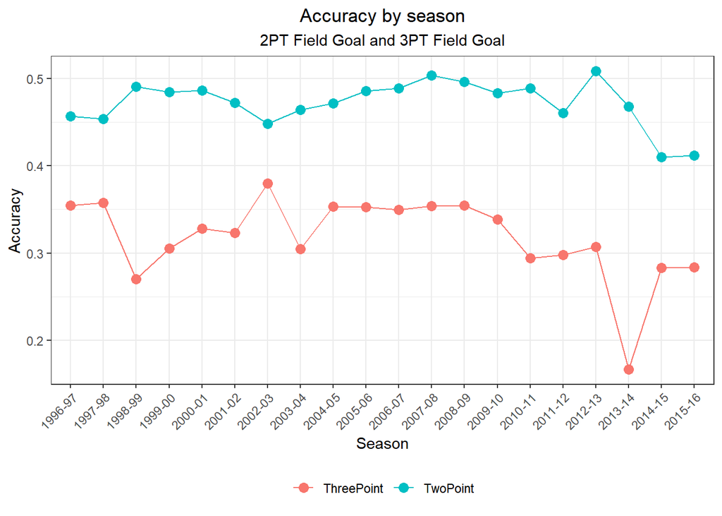

```r
kobe_clean%>%
  group_by(season) %>%
  summarise(TwoPoint=mean(shot_made_flag[shot_type=="2PT Field Goal"]),
            ThreePoint=mean(shot_made_flag[shot_type=="3PT Field Goal"])) %>%
  ggplot(aes(x=season, group=1)) +
  geom_line(aes(y=TwoPoint, colour="TwoPoint")) +
  geom_line(aes(y=ThreePoint, colour="ThreePoint")) +
  geom_point(aes(y=TwoPoint, colour="TwoPoint"), size=3) +
  geom_point(aes(y=ThreePoint, colour="ThreePoint"), size=3) +
  labs(title="Accuracy by season",
       subtitle="2PT Field Goal and 3PT Field Goal",
       x="Season", y="Accuracy") +
  theme_bw() +
  theme(legend.title=element_blank(),
        legend.position="bottom",
        axis.text.x=element_text(angle=45, hjust=1),
        plot.title=element_text(hjust=0.5),
        plot.subtitle=element_text(hjust=0.5))
```

### 4.1.3常规赛、季后赛命中率随赛季变化的趋势

```
## Warning: Removed 4 rows containing missing values or values outside the scale range
## (`geom_line()`).
```

```
## Warning: Removed 5 rows containing missing values or values outside the scale range
## (`geom_point()`).
```

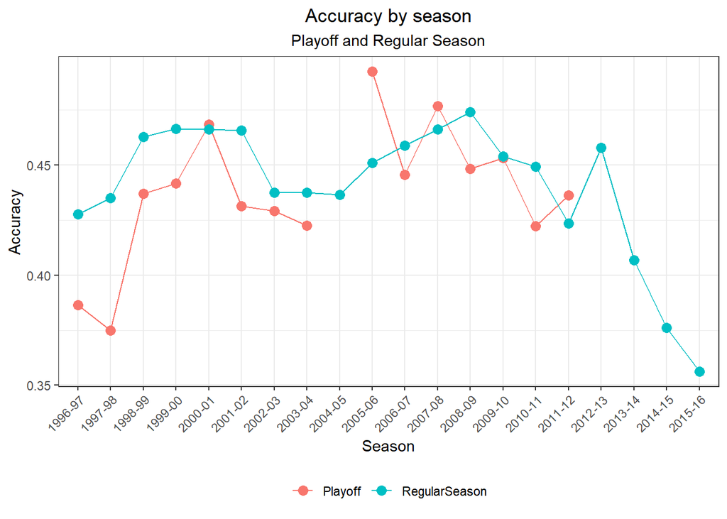

```r
kobe_clean %>%
  group_by(season) %>%
  summarise(Playoff=mean(shot_made_flag[playoffs==1]),
            RegularSeason=mean(shot_made_flag[playoffs==0])) %>%
  ggplot(aes(x=season, group=1)) +
  geom_line(aes(y=Playoff, colour="Playoff")) +
  geom_line(aes(y=RegularSeason, colour="RegularSeason")) +
  geom_point(aes(y=Playoff, colour="Playoff"), size=3) +
  geom_point(aes(y=RegularSeason, colour="RegularSeason"), size=3) +
  labs(title="Accuracy by season",
       subtitle="Playoff and Regular Season",
       x="Season", y="Accuracy") +
  theme_bw() +
  theme(legend.title=element_blank(),
        legend.position="bottom",
        axis.text.x=element_text(angle=45, hjust=1),
        plot.title=element_text(hjust=0.5),
        plot.subtitle=element_text(hjust=0.5))
```

## 4.2场内变化

### 4.2.1一分钟内命中率

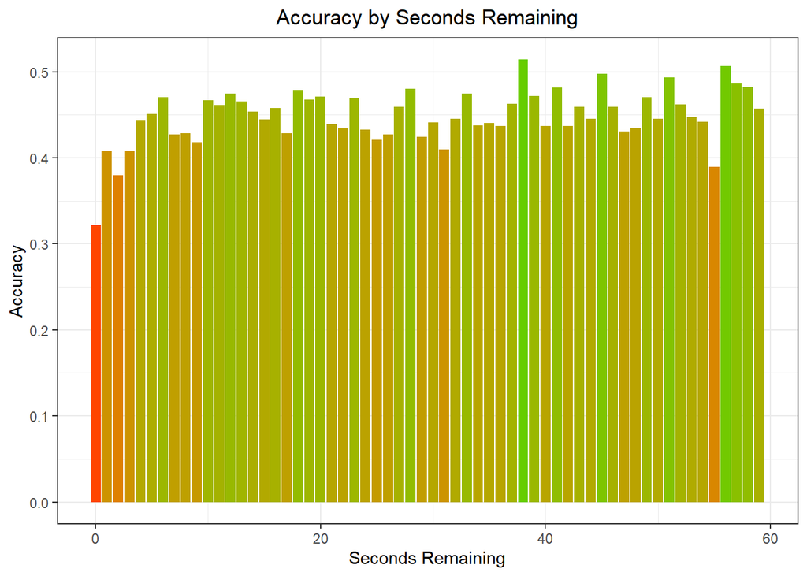

```r
# Check for and remove NA values in the shot_made_flag column
kobe_clean <- kobe %>% filter(!is.na(shot_made_flag))

# Group by seconds_remaining and calculate Accuracy
accuracy_data <- kobe_clean %>%
  group_by(seconds_remaining) %>%
  summarise(Accuracy = mean(shot_made_flag, na.rm = TRUE))

# Plot the data
ggplot(accuracy_data, aes(x = seconds_remaining, y = Accuracy)) +
  geom_bar(aes(fill = Accuracy), stat = "identity") +
  scale_fill_gradient(low = "orangered", high = "chartreuse3") +
  labs(title = "Accuracy by Seconds Remaining", x = "Seconds Remaining") +
  theme_bw() +
  theme(legend.position = "none",
        plot.title = element_text(hjust = 0.5))
```

- 由于列“shot_made_flag”中包含缺失值，故我们先对数据集进行数据清洗，得到kobe_clean。
- 可以看到，除开最后三秒，科比的命中率几乎都在45%左右，说明科比的体能充沛。故最后三秒的下降往往由于出手时间较短，导致出手仓促，投篮动作发生变形。

### 4.2.2一节内命中率

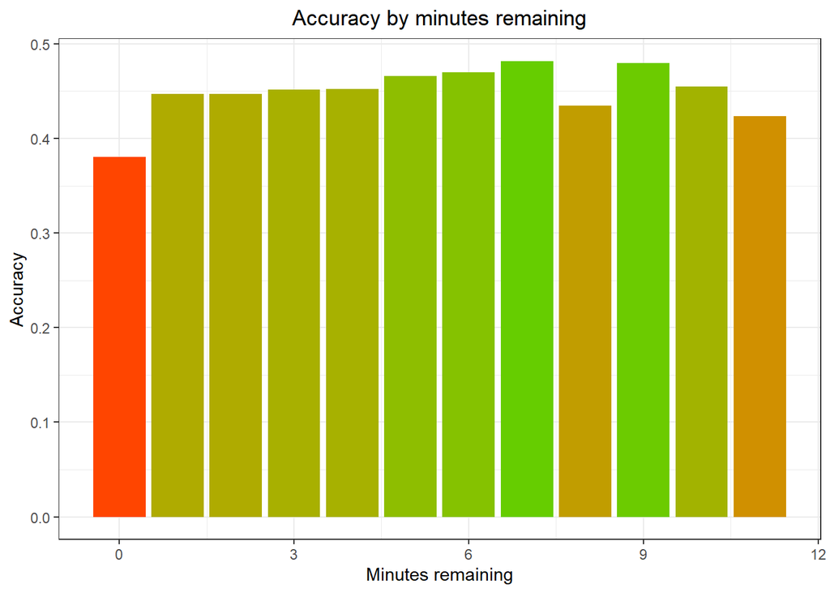

```r
kobe_clean %>%
  group_by(minutes_remaining) %>%
  summarise(Accuracy=mean(shot_made_flag)) %>%
  ggplot(aes(x=minutes_remaining, y=Accuracy)) +
  geom_bar(aes(fill=Accuracy), stat="identity") +
  scale_fill_gradient(low="orangered", high="chartreuse3") +
  labs(title="Accuracy by minutes remaining", x="Minutes remaining")  +
  theme_bw() +
  theme(legend.position="none",
        plot.title=element_text(hjust=0.5))
```

- 可以看到科比在每一节开始需要3分钟来找到手感，随后3到11分钟将命中率维持在45%左右的高效水平，最后一分钟的下滑则可以理解，毕竟没有人能整节都保持高效。

# 第五章 科比面对不同对手的表现

## 5.1面对不同对手的出手分配

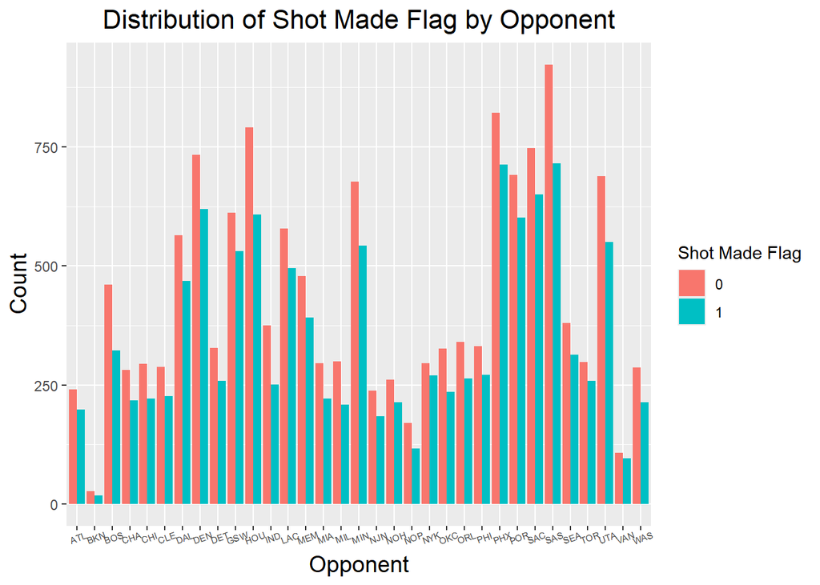

```r
ggplot(kobe_clean, aes(factor(opponent), fill=factor(shot_made_flag))) +
  geom_bar(position="dodge") +
  theme(axis.text.x = element_text(angle = 20, hjust = 0.5, size = 5.5), # 调整标签角度和字体大小
        axis.title.x = element_text(size = 14), # 调整横坐标标题大小
        axis.title.y = element_text(size = 14), # 调整纵坐标标题大小
        plot.title = element_text(hjust = 0.5, size = 16)) + # 调整标题大小并居中
  labs(x = "Opponent", y = "Count", fill = "Shot Made Flag") +
  ggtitle("Distribution of Shot Made Flag by Opponent")
```

- 可以看出队伍BOS,DAL,DEN,MIN,PHX,SAS,UTA对科比的限制比较好，在大量的交手中迫使科比投丢了更多的球。

## 5.2面对不同对手的投篮方式

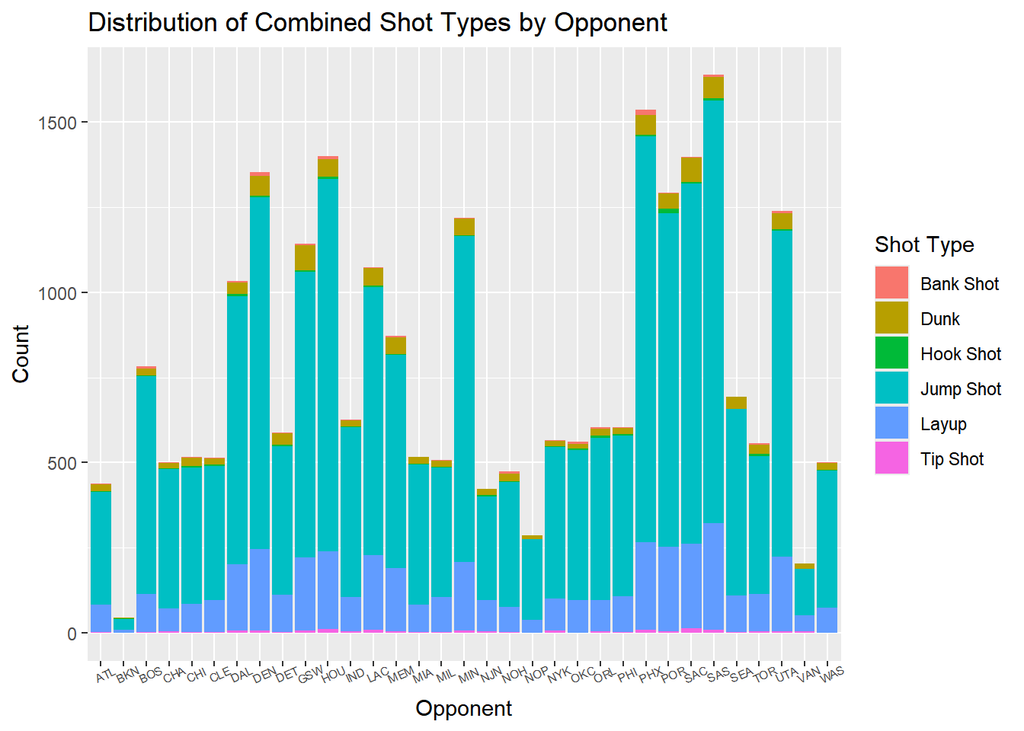

```r
# 创建条形图，并调整横坐标标签的角度和大小
 ggplot(kobe_clean, aes(factor(opponent), fill=factor(combined_shot_type))) +
  geom_bar() +
  theme(axis.text.x = element_text(angle = 25, hjust = 0.4, size = 5.5)) +
  labs(x = "Opponent", y = "Count", fill = "Shot Type") +
  ggtitle("Distribution of Combined Shot Types by Opponent")
```

- 面对不同球队不同风格的防守，科比几乎都能完成所有的大类投篮动作，再次说明科比的技术全能，当之无愧的进攻“超纲”。同时面对不同队伍科比的各种大类投篮方式占比不同，说明科比懂得根据敌人的防守策略做出合理的投篮选择。